# Final_Project

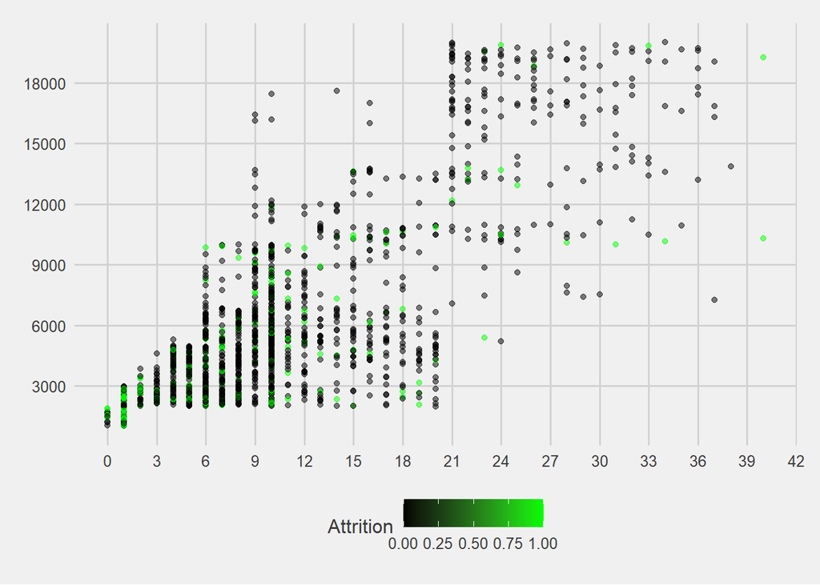

```r
#These trend towards low earners, and people within the first 3-6 years of their professional life.
# Specifically three years.

attr_year <- ggplot(IBMdata) +
  aes(x=TotalWorkingYears, y=MonthlyIncome,
      color=Attrition ) +
  geom_point(alpha = 0.5) + scale_color_continuous(name="Attrition", low = "black", high ='#00ff00')+
  scale_x_continuous(n.breaks = 15) + scale_y_continuous(n.breaks = 8)+ theme_fivethirtyeight()

attr_year
```

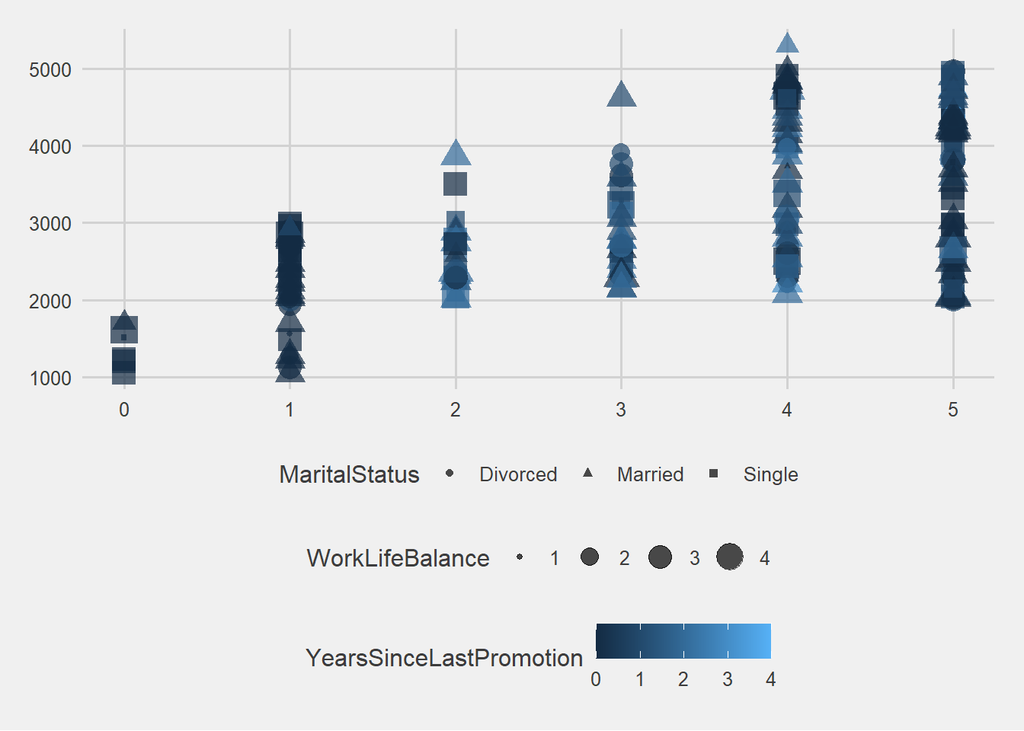

```r
##Individuals within their first 6 years that are staying report a high work life balance, trend towards not being single, and have been promoted in the past 2 years.

those.who.stay <- ggplot(stay3) +
  aes(x=TotalWorkingYears, y=MonthlyIncome,
      size=WorkLifeBalance, color=YearsSinceLastPromotion, shape = MaritalStatus) +
  geom_point(alpha = 0.7)+ theme_fivethirtyeight()

those.who.stay
```

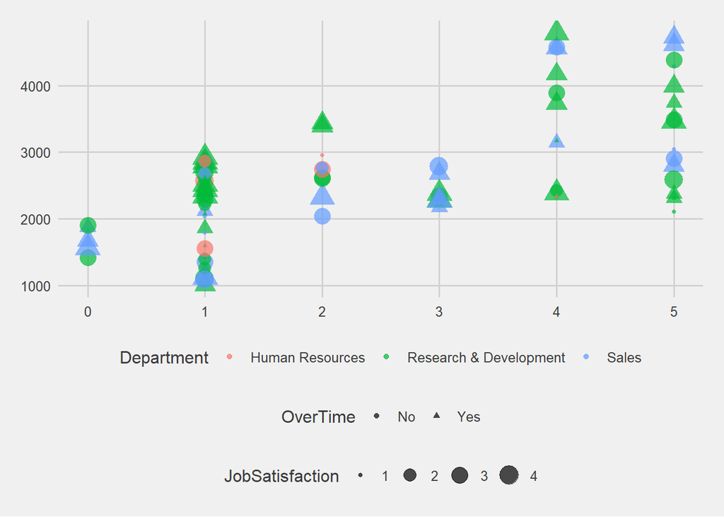

```r
### Leaving from the RD department in the first year, they are working OverTime
### generally they are satisfied with their job but making less than 3K a month.
## They have 1 total working year.

leave3 <- isoLeft.attrition[isoLeft.attrition$TotalWorkingYears<6,]
those.who.leave <- ggplot(leave3) +
  aes(x=TotalWorkingYears, y=MonthlyIncome,
      size=JobSatisfaction, color=Department, shape = OverTime) +
  geom_point(alpha = 0.7)+ theme_fivethirtyeight()

those.who.leave
```

## Q2

2. Is there a typecast of employee that, on average, will stay with the company over time? What do they look like, what attributes do they have?

#Create a set that has factors

```r
isoStay_trans <- as(isoStay.t,"transactions")
str(isoStay_trans)
```

```
## Formal class 'transactions' [package "arules"] with 3 slots
##   ..@ data       :Formal class 'ngCMatrix' [package "Matrix"] with 5 slots
##   .. .. ..@ i       : int [1:32058] 0 2 5 14 36 42 49 52 54 58 ...
##   .. .. ..@ p       : int [1:1234] 0 26 52 78 104 130 156 182 208 234 ...
##   .. .. ..@ Dim     : int [1:2] 254 1233
##   .. .. ..@ Dimnames:List of 2
##   .. .. .. ..$ : NULL
##   .. .. .. ..$ : NULL
##   .. .. ..@ factors : list()
##   ..@ itemInfo   :'data.frame':  254 obs. of  3 variables:
##   .. ..$ labels   : chr [1:254] "Attrition=0" "BusinessTravel=Non-Travel" "BusinessTravel=Travel_Frequently" "BusinessTravel=Travel_Rarely" ...
##   .. ..$ variables: Factor w/ 26 levels "Attrition","BusinessTravel",..: 1 2 2 2 3 3 3 4 4 4 ...
##   .. ..$ levels   : Factor w/ 65 levels "0","1","10","11",..: 1 53 63 64 43 55 58 2 13 24 ...
##   ..@ itemsetInfo:'data.frame':  1233 obs. of  1 variable:
##   .. ..$ transactionID: chr [1:1233] "1" "2" "3" "4" ...
```

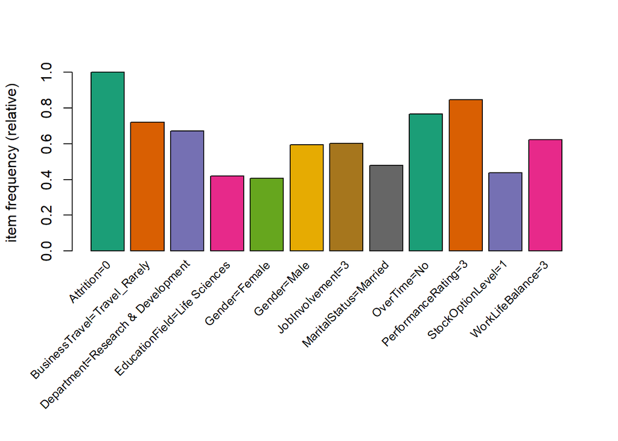

```r
itemFrequencyPlot(isoStay_trans, support = 0.4, cex.names = 0.8, col = brewer.pal(8,'Dark2'))
```

```r
### as() convert to something, instead of a as.function, the second argument,
### transactions says we want to convert it to a transaction.
#### 2. Convert to transaction
isoStay_trans <- as(isoStay.t,"transactions")
str(isoStay_trans)
```

[output not shown]

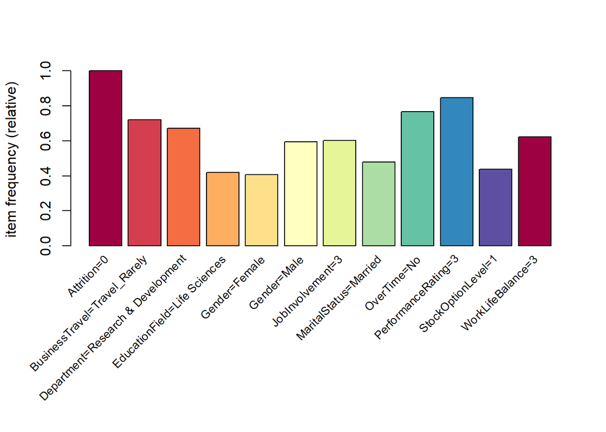

```r
itemFrequencyPlot(isoStay_trans, support = 0.4, cex.names = 0.8, col= brewer.pal(11,'Spectral'))
```

## Q3

3.Is there a typecast that is most likely to leave the company? # What do they look like, what attributes do they have?

```r
isoLeft.t <- data.frame(isoLeft.attrition)

##### 1. To convert, all numbers / strings need to be converted to factors.
isoLeft.t$Age <- as.factor(isoLeft.t$Age)
isoLeft.t$Attrition <- as.factor(isoLeft.t$Attrition)
isoLeft.t$BusinessTravel<- as.factor(isoLeft.t$BusinessTravel)
isoLeft.t$DailyRate <- as.factor(isoLeft.t$DailyRate)
isoLeft.t$Department<- as.factor(isoLeft.t$Department)
isoLeft.t$DistanceFromHome<- as.factor(isoLeft.t$DistanceFromHome)
isoLeft.t$Education<- as.factor(isoLeft.t$Education)
isoLeft.t$EducationField<- as.factor(isoLeft.t$EducationField)
isoLeft.t$EnvironmentSatisfaction<- as.factor(isoLeft.t$EnvironmentSatisfaction)
isoLeft.t$Gender<- as.factor(isoLeft.t$Gender)
isoLeft.t$HourlyRate<- as.factor(isoLeft.t$HourlyRate)
isoLeft.t$JobInvolvement<- as.factor(isoLeft.t$JobInvolvement)
isoLeft.t$JobLevel<- as.factor(isoLeft.t$JobLevel)
isoLeft.t$JobRole<- as.factor(isoLeft.t$JobRole)
isoLeft.t$JobSatisfaction<- as.factor(isoLeft.t$JobSatisfaction)
isoLeft.t$MaritalStatus<- as.factor(isoLeft.t$MaritalStatus)
isoLeft.t$MonthlyIncome<- as.factor(isoLeft.t$MonthlyIncome)
isoLeft.t$MonthlyRate<- as.factor(isoLeft.t$MonthlyRate)
isoLeft.t$NumCompaniesWorked<- as.factor(isoLeft.t$NumCompaniesWorked)
isoLeft.t$Over18<- as.factor(isoLeft.t$Over18)
isoLeft.t$OverTime<- as.factor(isoLeft.t$OverTime)
isoLeft.t$PercentSalaryHike<- as.factor(isoLeft.t$PercentSalaryHike)
isoLeft.t$PerformanceRating<- as.factor(isoLeft.t$PerformanceRating)
isoLeft.t$RelationshipSatisfaction<- as.factor(isoLeft.t$RelationshipSatisfaction)
isoLeft.t$StandardHours<- as.factor(isoLeft.t$StandardHours)
isoLeft.t$StockOptionLevel<- as.factor(isoLeft.t$StockOptionLevel)
isoLeft.t$TotalWorkingYears<- as.factor(isoLeft.t$TotalWorkingYears)
isoLeft.t$TrainingTimesLastYear<- as.factor(isoLeft.t$TrainingTimesLastYear)
isoLeft.t$WorkLifeBalance<- as.factor(isoLeft.t$WorkLifeBalance)
isoLeft.t$YearsInCurrentRole<- as.factor(isoLeft.t$YearsInCurrentRole)
isoLeft.t$YearsSinceLastPromotion<- as.factor(isoLeft.t$YearsSinceLastPromotion)
isoLeft.t$YearsWithCurrManager<- as.factor(isoLeft.t$YearsWithCurrManager)
isoLeft.t$YearsAtCompany<- as.factor(isoLeft.t$YearsAtCompany)
## Remove Age and Years Working
isoLeft.t<- isoLeft.t[,-9:-10]
## Remove Salary and things I don't like...
isoLeft.t <- isoLeft.t[,-1] # Age
isoLeft.t <- isoLeft.t[,-3]# Daily Rate
isoLeft.t <- isoLeft.t[,-9]# Hourly Rate
isoLeft.t <- isoLeft.t[,-14:-15]# Monthly Rate
isoLeft.t<- isoLeft.t[,-15]#Over18
isoLeft.t <-isoLeft.t[,-19]#Standard Hours

### as() convert to something, instead of a as.function, the second argument,
### transactions says we want to convert it to a transaction.
#### 2. Convert to transaction
isoLeft_trans <- as(isoLeft.t,"transactions")
```

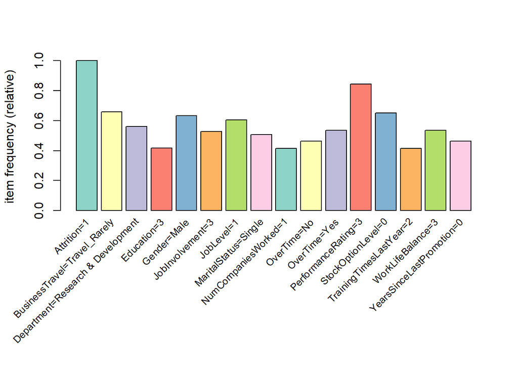

```r
itemFrequencyPlot(isoLeft_trans, support = 0.4, cex.names = 0.8, col = brewer.pal(8,'Set3'))
```

#Isolate the same behaviors but for junior employees that have left the company.

```r
 years3 <- isoLeft.attrition[isoLeft.attrition$YearsAtCompany<3,]

isoLeft.t <- data.frame(years3)

##### To convert, all numbers / strings need to be converted to factors.
isoLeft.t$Age <- as.factor(isoLeft.t$Age)
isoLeft.t$Attrition <- as.factor(isoLeft.t$Attrition)
isoLeft.t$BusinessTravel<- as.factor(isoLeft.t$BusinessTravel)
isoLeft.t$DailyRate <- as.factor(isoLeft.t$DailyRate)
isoLeft.t$Department<- as.factor(isoLeft.t$Department)
isoLeft.t$DistanceFromHome<- as.factor(isoLeft.t$DistanceFromHome)
isoLeft.t$Education<- as.factor(isoLeft.t$Education)
isoLeft.t$EducationField<- as.factor(isoLeft.t$EducationField)
isoLeft.t$EnvironmentSatisfaction<- as.factor(isoLeft.t$EnvironmentSatisfaction)
isoLeft.t$Gender<- as.factor(isoLeft.t$Gender)
isoLeft.t$HourlyRate<- as.factor(isoLeft.t$HourlyRate)
isoLeft.t$JobInvolvement<- as.factor(isoLeft.t$JobInvolvement)
isoLeft.t$JobLevel<- as.factor(isoLeft.t$JobLevel)
isoLeft.t$JobRole<- as.factor(isoLeft.t$JobRole)
isoLeft.t$JobSatisfaction<- as.factor(isoLeft.t$JobSatisfaction)
isoLeft.t$MaritalStatus<- as.factor(isoLeft.t$MaritalStatus)
isoLeft.t$MonthlyIncome<- as.factor(isoLeft.t$MonthlyIncome)
isoLeft.t$MonthlyRate<- as.factor(isoLeft.t$MonthlyRate)
isoLeft.t$NumCompaniesWorked<- as.factor(isoLeft.t$NumCompaniesWorked)
isoLeft.t$Over18<- as.factor(isoLeft.t$Over18)
isoLeft.t$OverTime<- as.factor(isoLeft.t$OverTime)
isoLeft.t$PercentSalaryHike<- as.factor(isoLeft.t$PercentSalaryHike)
isoLeft.t$PerformanceRating<- as.factor(isoLeft.t$PerformanceRating)
isoLeft.t$RelationshipSatisfaction<- as.factor(isoLeft.t$RelationshipSatisfaction)
isoLeft.t$StandardHours<- as.factor(isoLeft.t$StandardHours)
isoLeft.t$StockOptionLevel<- as.factor(isoLeft.t$StockOptionLevel)
isoLeft.t$TotalWorkingYears<- as.factor(isoLeft.t$TotalWorkingYears)
isoLeft.t$TrainingTimesLastYear<- as.factor(isoLeft.t$TrainingTimesLastYear)
isoLeft.t$WorkLifeBalance<- as.factor(isoLeft.t$WorkLifeBalance)
isoLeft.t$YearsInCurrentRole<- as.factor(isoLeft.t$YearsInCurrentRole)
isoLeft.t$YearsSinceLastPromotion<- as.factor(isoLeft.t$YearsSinceLastPromotion)
isoLeft.t$YearsWithCurrManager<- as.factor(isoLeft.t$YearsWithCurrManager)
isoLeft.t$YearsAtCompany<- as.factor(isoLeft.t$YearsAtCompany)
## Remove Age and Years Working
isoLeft.t<- isoLeft.t[,-9:-10]
## Remove Salary and things I don't like...
isoLeft.t <- isoLeft.t[,-1] # Age
isoLeft.t <- isoLeft.t[,-3]# Daily Rate
isoLeft.t <- isoLeft.t[,-9]# Hourly Rate
isoLeft.t <- isoLeft.t[,-14:-15]# Monthly Rate
isoLeft.t<- isoLeft.t[,-15]#Over18
isoLeft.t <-isoLeft.t[,-19]#Standard Hours

### as() convert to something, instead of a as.function, the second argument,
### transactions says we want to convert it to a transaction.
#### 2. Convert to transaction
isoLeft_3Yrs <- as(isoLeft.t,"transactions")
```

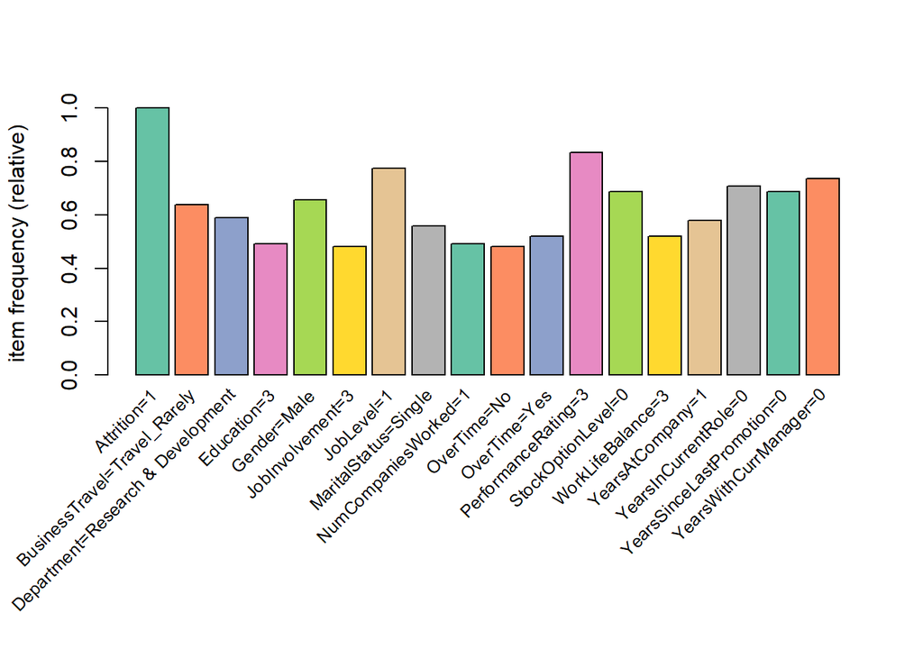

```r
itemFrequencyPlot(isoLeft_3Yrs, support = 0.4, cex.names = 0.8, col = brewer.pal(8,'Set2'))
```

# Generate rules for leaving with Associative Rules Datamining

```r
IBM.t <- IBMdata

##### 1. To convert, all numbers / strings need to be converted to factors.
IBM.t$Age <- as.factor(IBM.t$Age)
IBM.t$Attrition <- as.factor(IBM.t$Attrition)
IBM.t$BusinessTravel<- as.factor(IBM.t$BusinessTravel)
IBM.t$DailyRate <- as.factor(IBM.t$DailyRate)
IBM.t$Department<- as.factor(IBM.t$Department)
IBM.t$DistanceFromHome<- as.factor(IBM.t$DistanceFromHome)
IBM.t$Education<- as.factor(IBM.t$Education)
IBM.t$EducationField<- as.factor(IBM.t$EducationField)
IBM.t$EnvironmentSatisfaction<- as.factor(IBM.t$EnvironmentSatisfaction)
IBM.t$Gender<- as.factor(IBM.t$Gender)
IBM.t$HourlyRate<- as.factor(IBM.t$HourlyRate)
IBM.t$JobInvolvement<- as.factor(IBM.t$JobInvolvement)
IBM.t$JobLevel<- as.factor(IBM.t$JobLevel)
IBM.t$JobRole<- as.factor(IBM.t$JobRole)
IBM.t$JobSatisfaction<- as.factor(IBM.t$JobSatisfaction)
IBM.t$MaritalStatus<- as.factor(IBM.t$MaritalStatus)
IBM.t$MonthlyIncome<- as.factor(IBM.t$MonthlyIncome)
IBM.t$MonthlyRate<- as.factor(IBM.t$MonthlyRate)
IBM.t$NumCompaniesWorked<- as.factor(IBM.t$NumCompaniesWorked)
IBM.t$Over18<- as.factor(IBM.t$Over18)
IBM.t$OverTime<- as.factor(IBM.t$OverTime)
IBM.t$PercentSalaryHike<- as.factor(IBM.t$PercentSalaryHike)
IBM.t$PerformanceRating<- as.factor(IBM.t$PerformanceRating)
IBM.t$RelationshipSatisfaction<- as.factor(IBM.t$RelationshipSatisfaction)
IBM.t$StandardHours<- as.factor(IBM.t$StandardHours)
IBM.t$StockOptionLevel<- as.factor(IBM.t$StockOptionLevel)
IBM.t$TotalWorkingYears<- as.factor(IBM.t$TotalWorkingYears)
IBM.t$TrainingTimesLastYear<- as.factor(IBM.t$TrainingTimesLastYear)
IBM.t$WorkLifeBalance<- as.factor(IBM.t$WorkLifeBalance)
IBM.t$YearsInCurrentRole<- as.factor(IBM.t$YearsInCurrentRole)
IBM.t$YearsSinceLastPromotion<- as.factor(IBM.t$YearsSinceLastPromotion)
IBM.t$YearsWithCurrManager<- as.factor(IBM.t$YearsWithCurrManager)
IBM.t$YearsAtCompany<- as.factor(IBM.t$YearsAtCompany)
## Remove Age and Years Working
IBM.t<- IBM.t[,-9:-10]
## Remove Salary and things I don't like...
IBM.t<- IBM.t[,-1] # Age
IBM.t<- IBM.t[,-3]# Daily Rate
IBM.t<- IBM.t[,-9]# Hourly Rate
IBM.t<- IBM.t[,-14:-15]# Monthly Rate
IBM.t<- IBM.t[,-15]#Over18
IBM.t<- IBM.t[,-19]#Standard Hours


##Make IBM list a transaction list.

IBM_trans <- as(IBM.t,"transactions")
```

```r
### How often does any of this stuff occur within the dataset?

IBM_means <- rowMeans(IBM_trans@data)
IBM_labels <- IBM_trans@itemInfo$labels
IBM_levels <- IBM_trans@itemInfo$levels

IBM_df <- data.frame(IBM_means, IBM_labels, IBM_levels)
```

```r
### Would you look at that, What percentage of the company is staying or leaving.
IBM_df[1:2,]
```

```
##   IBM_means  IBM_labels IBM_levels
## 1 0.8387755 Attrition=0          0
## 2 0.1612245 Attrition=1          1
```

```r
#Most common factors across the whole set.
IBM_desc_df <- IBM_df[order(-(IBM_df$IBM_means)),]
head(IBM_desc_df, 20)
```

```
##     IBM_means                        IBM_labels             IBM_levels
## 107 0.8462585               PerformanceRating=3                      3
## 1   0.8387755                       Attrition=0                      0
## 90  0.7170068                       OverTime=No                     No
## 5   0.7095238      BusinessTravel=Travel_Rarely          Travel_Rarely
## 7   0.6537415 Department=Research & Development Research & Development
## 166 0.6074830                 WorkLifeBalance=3                      3
## 54  0.6000000                       Gender=Male                   Male
## 57  0.5904762                  JobInvolvement=3                      3
## 78  0.4578231             MaritalStatus=Married                Married
## 113 0.4292517                StockOptionLevel=0                      0
## 44  0.4122449      EducationField=Life Sciences          Life Sciences
## 114 0.4054422                StockOptionLevel=1                      1
## 53  0.4000000                     Gender=Female                 Female
## 224 0.3952381         YearsSinceLastPromotion=0                      0
## 40  0.3891156                       Education=3                      3
## 159 0.3721088           TrainingTimesLastYear=2                      2
## 59  0.3693878                        JobLevel=1                      1
## 60  0.3632653                        JobLevel=2                      2
## 81  0.3544218              NumCompaniesWorked=1                      1
## 160 0.3340136           TrainingTimesLastYear=3                      3
```

# Associative rules for interactions between factorials across the data set.

```r
IBM_rules <- apriori(IBM_trans, parameter = list(support = 0.09, confidence = 0.6))
```

```
## Apriori
##
## Parameter specification:
##  confidence minval smax arem  aval originalSupport maxtime support minlen
##         0.6    0.1    1 none FALSE            TRUE       5    0.09      1
##  maxlen target  ext
##      10  rules TRUE
##
## Algorithmic control:
##  filter tree heap memopt load sort verbose
##     0.1 TRUE TRUE  FALSE TRUE    2    TRUE
##
## Absolute minimum support count: 132
##
## set item appearances ...[0 item(s)] done [0.00s].
## set transactions ...[257 item(s), 1470 transaction(s)] done [0.00s].
## sorting and recoding items ... [78 item(s)] done [0.00s].
## creating transaction tree ... done [0.00s].
## checking subsets of size 1 2 3 4 5 6 7 done [0.02s].
## writing ... [10239 rule(s)] done [0.00s].
## creating S4 object  ... done [0.01s].
```

```
## To reduce overplotting, jitter is added! Use jitter = 0 to prevent jitter.
```

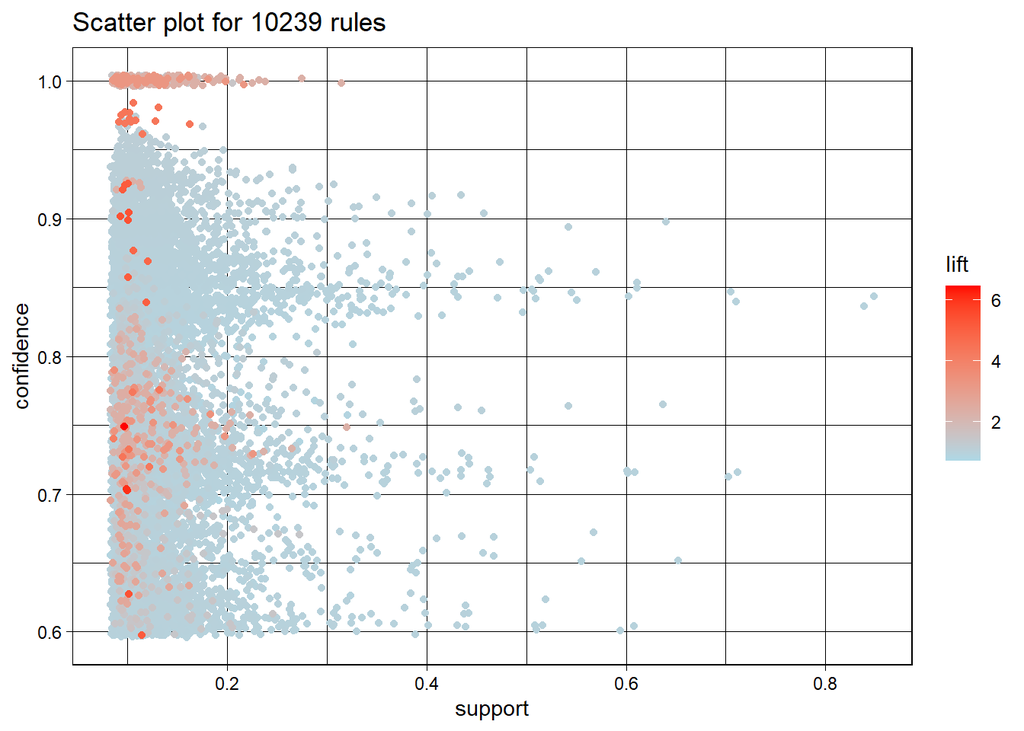

```r
par(mfrow=c(1,1))
plot(IBM_rules)+
  scale_color_gradient(low = "lightblue", high = "red")
```

# Isolated rules that had high lift.

```
## To reduce overplotting, jitter is added! Use jitter = 0 to prevent jitter.
```

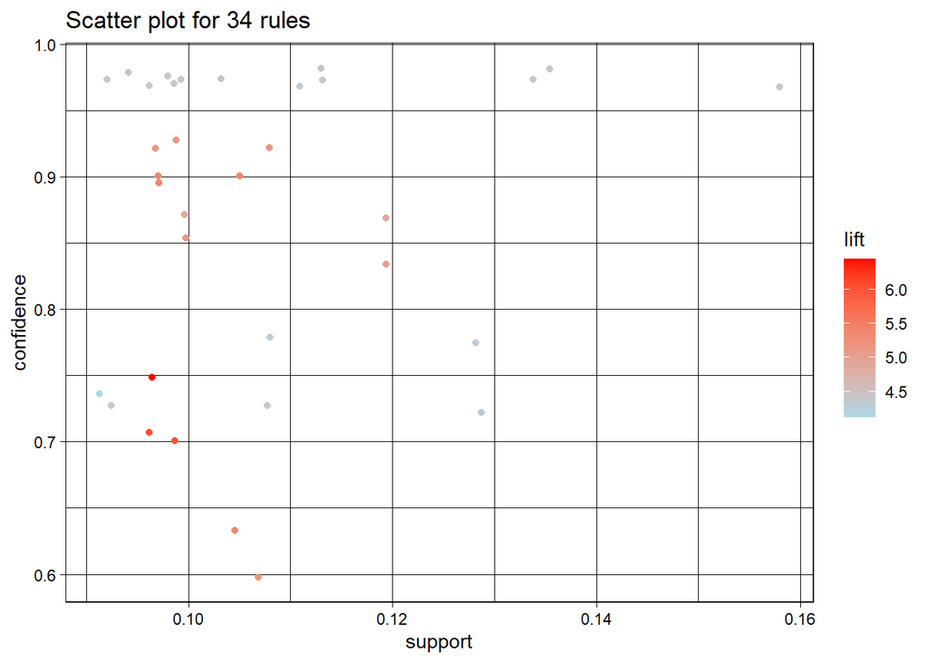

```r
goodRules <- IBM_rules[quality(IBM_rules)$lift >4]

plot(goodRules)+
  scale_color_gradient(low = "lightblue", high = "red")
```

# Rules for when people leave the company:

```r
LeaveRules <- apriori(IBM_trans, parameter = list(support = 0.04, confidence = 0.3),
                     appearance=list(rhs='Attrition=1'))
```

```
## Apriori
##
## Parameter specification:
##  confidence minval smax arem  aval originalSupport maxtime support minlen
##         0.3    0.1    1 none FALSE            TRUE       5    0.04      1
##  maxlen target  ext
##      10  rules TRUE
##
## Algorithmic control:
##  filter tree heap memopt load sort verbose
##     0.1 TRUE TRUE  FALSE TRUE    2    TRUE
##
## Absolute minimum support count: 58
##
## set item appearances ...[1 item(s)] done [0.00s].
## set transactions ...[257 item(s), 1470 transaction(s)] done [0.00s].
## sorting and recoding items ... [134 item(s)] done [0.00s].
## creating transaction tree ... done [0.00s].
## checking subsets of size 1 2 3 4 5 6 7 8 done [0.12s].
## writing ... [31 rule(s)] done [0.00s].
## creating S4 object  ... done [0.00s].
```

```r
inspect(LeaveRules)
```

```
##      lhs                                     rhs              support confidence   coverage     lift count
## [1]  {YearsAtCompany=1}                   => {Attrition=1} 0.04013605  0.3450292 0.11632653 2.140055    59
## [2]  {YearsWithCurrManager=0}             => {Attrition=1} 0.05782313  0.3231939 0.17891156 2.004620    85
## [3]  {OverTime=Yes}                       => {Attrition=1} 0.08639456  0.3052885 0.28299320 1.893561   127
## [4]  {YearsInCurrentRole=0,
##       YearsWithCurrManager=0}             => {Attrition=1} 0.04557823  0.3544974 0.12857143 2.198781    67
## [5]  {YearsInCurrentRole=0,
##       YearsSinceLastPromotion=0}          => {Attrition=1} 0.04217687  0.3084577 0.13673469 1.913219    62
## [6]  {JobLevel=1,
##       YearsWithCurrManager=0}             => {Attrition=1} 0.04421769  0.4333333 0.10204082 2.687764    65
## [7]  {YearsSinceLastPromotion=0,
##       YearsWithCurrManager=0}             => {Attrition=1} 0.04421769  0.3110048 0.14217687 1.929017    65
## [8]  {PerformanceRating=3,
##       YearsWithCurrManager=0}             => {Attrition=1} 0.04829932  0.3256881 0.14829932 2.020091    71
## [9]  {MaritalStatus=Single,
##       OverTime=Yes}                       => {Attrition=1} 0.04421769  0.4961832 0.08911565 3.077592    65
## [10] {JobLevel=1,
##       OverTime=Yes}                       => {Attrition=1} 0.05578231  0.5256410 0.10612245 3.260305    82
## [11] {OverTime=Yes,
##       YearsSinceLastPromotion=0}          => {Attrition=1} 0.04013605  0.3450292 0.11632653 2.140055    59
## [12] {OverTime=Yes,
##       StockOptionLevel=0}                 => {Attrition=1} 0.05578231  0.4505495 0.12380952 2.794547    82
## [13] {Gender=Male,
##       OverTime=Yes}                       => {Attrition=1} 0.05442177  0.3389831 0.16054422 2.102553    80
## [14] {Department=Sales,
##       StockOptionLevel=0}                 => {Attrition=1} 0.04353741  0.3248731 0.13401361 2.015036    64
## [15] {JobLevel=1,
##       MaritalStatus=Single}               => {Attrition=1} 0.05306122  0.3861386 0.13741497 2.395037    78
## [16] {MaritalStatus=Single,
##       YearsSinceLastPromotion=0}          => {Attrition=1} 0.04149660  0.3128205 0.13265306 1.940279    61
## [17] {JobLevel=1,
##       YearsSinceLastPromotion=0}          => {Attrition=1} 0.05306122  0.3000000 0.17687075 1.860759    78
## [18] {JobLevel=1,
##       StockOptionLevel=0}                 => {Attrition=1} 0.06462585  0.3696498 0.17482993 2.292765    95
## [19] {YearsInCurrentRole=0,
##       YearsSinceLastPromotion=0,
##       YearsWithCurrManager=0}             => {Attrition=1} 0.04013605  0.3371429 0.11904762 2.091139    59
## [20] {MaritalStatus=Single,
##       OverTime=Yes,
##       StockOptionLevel=0}                 => {Attrition=1} 0.04421769  0.4961832 0.08911565 3.077592    65
```

[output cut: 19 more lines]

```
##       StockOptionLevel=0,
##       YearsSinceLastPromotion=0}          => {Attrition=1} 0.04149660  0.3128205 0.13265306 1.940279    61
## [28] {Department=Research & Development,
##       JobLevel=1,
##       StockOptionLevel=0}                 => {Attrition=1} 0.04489796  0.3283582 0.13673469 2.036652    66
## [29] {BusinessTravel=Travel_Rarely,
##       JobLevel=1,
##       StockOptionLevel=0}                 => {Attrition=1} 0.04421769  0.3457447 0.12789116 2.144492    65
## [30] {JobLevel=1,
##       PerformanceRating=3,
##       StockOptionLevel=0}                 => {Attrition=1} 0.05034014  0.3425926 0.14693878 2.124941    74
## [31] {JobLevel=1,
##       MaritalStatus=Single,
##       PerformanceRating=3,
##       StockOptionLevel=0}                 => {Attrition=1} 0.04081633  0.3468208 0.11768707 2.151167    60
```

```r
top.confidence <- sort(LeaveRules, decreasing = TRUE, na.last = NA, by = "confidence")

inspect(top.confidence)
```

```
##      lhs                                     rhs              support confidence   coverage     lift count
## [1]  {JobLevel=1,
##       OverTime=Yes}                       => {Attrition=1} 0.05578231  0.5256410 0.10612245 3.260305    82
## [2]  {JobLevel=1,
##       OverTime=Yes,
##       PerformanceRating=3}                => {Attrition=1} 0.04353741  0.5000000 0.08707483 3.101266    64
## [3]  {MaritalStatus=Single,
##       OverTime=Yes}                       => {Attrition=1} 0.04421769  0.4961832 0.08911565 3.077592    65
## [4]  {MaritalStatus=Single,
##       OverTime=Yes,
##       StockOptionLevel=0}                 => {Attrition=1} 0.04421769  0.4961832 0.08911565 3.077592    65
## [5]  {Department=Research & Development,
##       JobLevel=1,
##       OverTime=Yes}                       => {Attrition=1} 0.04217687  0.4920635 0.08571429 3.052039    62
## [6]  {OverTime=Yes,
##       StockOptionLevel=0}                 => {Attrition=1} 0.05578231  0.4505495 0.12380952 2.794547    82
## [7]  {JobLevel=1,
##       YearsWithCurrManager=0}             => {Attrition=1} 0.04421769  0.4333333 0.10204082 2.687764    65
## [8]  {OverTime=Yes,
##       PerformanceRating=3,
##       StockOptionLevel=0}                 => {Attrition=1} 0.04353741  0.4129032 0.10544218 2.561045    64
## [9]  {JobLevel=1,
##       MaritalStatus=Single}               => {Attrition=1} 0.05306122  0.3861386 0.13741497 2.395037    78
## [10] {JobLevel=1,
##       MaritalStatus=Single,
##       StockOptionLevel=0}                 => {Attrition=1} 0.05306122  0.3861386 0.13741497 2.395037    78
## [11] {JobLevel=1,
##       StockOptionLevel=0}                 => {Attrition=1} 0.06462585  0.3696498 0.17482993 2.292765    95
## [12] {YearsInCurrentRole=0,
##       YearsWithCurrManager=0}             => {Attrition=1} 0.04557823  0.3544974 0.12857143 2.198781    67
## [13] {JobLevel=1,
##       MaritalStatus=Single,
##       PerformanceRating=3}                => {Attrition=1} 0.04081633  0.3468208 0.11768707 2.151167    60
## [14] {JobLevel=1,
##       MaritalStatus=Single,
##       PerformanceRating=3,
##       StockOptionLevel=0}                 => {Attrition=1} 0.04081633  0.3468208 0.11768707 2.151167    60
## [15] {BusinessTravel=Travel_Rarely,
##       JobLevel=1,
##       StockOptionLevel=0}                 => {Attrition=1} 0.04421769  0.3457447 0.12789116 2.144492    65
```

[output cut: 19 more lines]

```
## [25] {Gender=Male,
##       OverTime=Yes,
##       PerformanceRating=3}                => {Attrition=1} 0.04353741  0.3168317 0.13741497 1.965159    64
## [26] {MaritalStatus=Single,
##       YearsSinceLastPromotion=0}          => {Attrition=1} 0.04149660  0.3128205 0.13265306 1.940279    61
## [27] {MaritalStatus=Single,
##       StockOptionLevel=0,
##       YearsSinceLastPromotion=0}          => {Attrition=1} 0.04149660  0.3128205 0.13265306 1.940279    61
## [28] {YearsSinceLastPromotion=0,
##       YearsWithCurrManager=0}             => {Attrition=1} 0.04421769  0.3110048 0.14217687 1.929017    65
## [29] {YearsInCurrentRole=0,
##       YearsSinceLastPromotion=0}          => {Attrition=1} 0.04217687  0.3084577 0.13673469 1.913219    62
## [30] {OverTime=Yes}                       => {Attrition=1} 0.08639456  0.3052885 0.28299320 1.893561   127
## [31] {JobLevel=1,
##       YearsSinceLastPromotion=0}          => {Attrition=1} 0.05306122  0.3000000 0.17687075 1.860759    78
```

[output not shown]

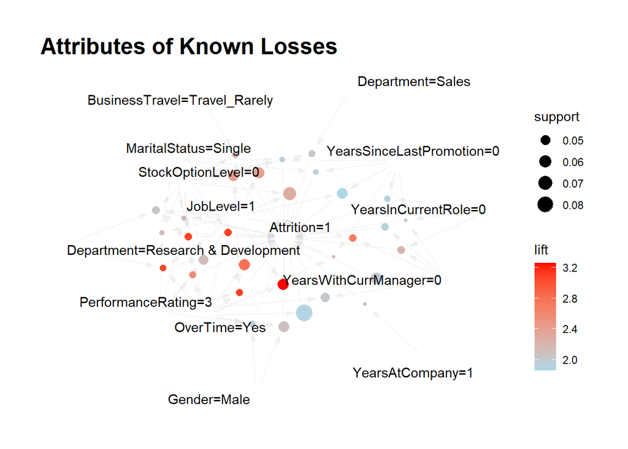

```r
plot(LeaveRules, method = 'graph', control = list(type='items'))+
  scale_color_gradient(low = "lightblue", high = "red")+ labs(title = "Attributes of Known Losses")
```